# Data Preprocessing with RStudio and “tidyverse”

## Jens Roeser

- Associate Professor in Psycholinguistics, Nottingham Institute of Psychology, Nottingham Trent University
- Focus: real-time planning in written language production
- Methods: Bayesian modelling, keystroke logging, eye tracking
- Teaching: (advanced) inferential statistics, data processing, data visualisation / dashboards
- Contact: `jens.roeser@ntu.ac.uk`
- [@sentwrite.bsky.social](https://bsky.app/profile/sentwrite.bsky.social)

[figure not shown]

Nottingham, UK

[figure not shown]

## Why Preprocess Data?

Most time spent working with data is not spent running statistical tests.

It is spent turning raw data into evidence we can trust.

Preprocessing matters because it:

- checks whether the data match what happened in the study
- documents decisions about exclusions, recoding, and missing values
- protects raw data from manual spreadsheet edits
- makes the workflow reproducible with open-source tools
- creates analysis-ready data for statistics, figures, and sharing

## Overview

ProjectKnow where files live

→

ReadCSV, Excel, SPSS

→

InspectCheck structure using e.g. glimpse

→

Process select, filter, mutate

→

SummariseUse summarise + .by

Throughout, I will first introduce functions which we then practice in exercises. Everything will be made available.

## Download The Workshop Folder From GitHub

Run one line in R:

```r
source(url("https://tinyurl.com/lplus-dataprocessing-ws"))
```

This creates:

- `lplus-2026-dataprocessing-ws/`

Then open the provided R project file for this workshop:

- `lplus-2026-dataprocessing-ws/lplus-2026-dataprocessing-ws.Rproj`

## RStudio Projects: `.Rproj`

An RStudio Project is a folder-based workspace.

What it does:

- marks the workshop folder as one self-contained project
- opens RStudio in the correct working directory

Why it matters:

- paths start from the project folder
- scripts, data, slides, and exercises stay together

## Why Projects Matter

With the project open, these paths work:

```r
read_csv("data/chinese_ldt.csv")
```

Without the project open, R may look in the wrong folder.

Check your current project folder:

```r
getwd()
```

Example:

```r
"/home/jensroes/lplus-2026-dataprocessing-ws"
```

## Creating A Project

For your own work later:

- **File > New Project**
- choose **New Directory** or **Existing Directory**
- keep raw data in a `data/` folder
- keep scripts in a `scripts/` or `r/` folder (today we use `exercises/`)
- open the `.Rproj` file before working

Project paths should be relative:

```r
read_csv("data/my_data.csv")
```

## Installing And Loading Packages

```r
install.packages("tidyverse")
```

Install packages once. Installing `tidyverse` also installs `readxl` and `haven`.

```r
library(tidyverse)
library(readxl)
library(haven)
```

Load packages in every new R session where you want to use their functions.

## What Is The Tidyverse?

The tidyverse is a collection of R packages for working with data.

- `readr` reads table-like text files, such as CSV files
- `readxl` reads Excel files
- `haven` reads SPSS, Stata, and SAS files
- `dplyr` transforms and summarises data
- `tidyr` changes data shape
- `ggplot2` makes plots

The packages share a common style: data first, instructions second.

## One Shared Pattern

Most tidyverse data processing functions follow one logic.

```r
verb(data, instructions)
```

Examples:

```r
select(data, variable)
filter(data, variable > 100)
mutate(data, new_variable = old_variable * 2)
summarise(data, mean_variable = mean(variable))
```

## Tidyverse And Base R

The tidyverse versions use consistent function names and avoid repeatedly typing the data frame name inside each instruction.

Goal

Base R

Tidyverse

select variables

`data[, c(“ppt_id”, “rt”)]`

`select(data, ppt_id, rt)`

filter rows

`data[data$rt > 2000, ]`

`filter(data, rt > 2000)`

create a variable

`data$rt_sec <- data$rt / 1000`

`mutate(data, rt_sec = rt / 1000)`

summarise

`mean(data$rt)`

`summarise(data, mean_rt = mean(rt))`

## Chinese Lexical Decision Task

Participants saw stimulus images in Chinese or Latin script and decided whether each one was a real word. Example item for *cat*:

Script

Word

Nonword

Chinese

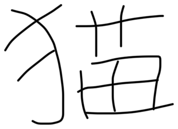

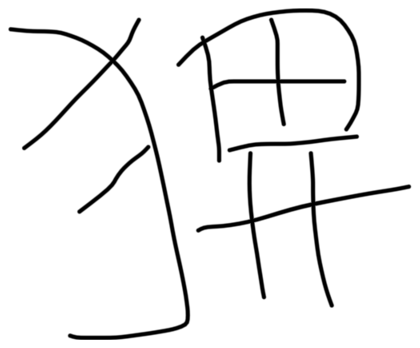

Latin

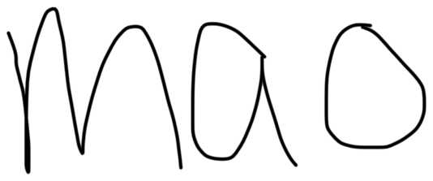

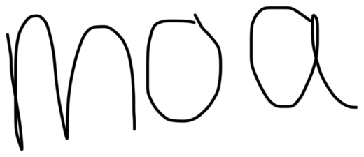

Each row in the dataset is one response trial from the online task.

**Note:** The original export was far more messy than what we will work with.

## More Variables

The data also contain useful predictors and item information.

Task variables:

- `ppt_id`, `trial`, `stimulus`, `script`, `lexicality`
- `word_eng`, `response`, `correct_response`

Participant variables:

- `age`, `language_status`

Outcome variables:

- `rt`, `rt_sec`, `correct`

## Reading CSV Files

```r
chinese_ldt <- read_csv("data/chinese_ldt.csv")
```

`read_csv` returns a tibble.

```r
class(chinese_ldt)
```

```
[1] "spec_tbl_df" "tbl_df"      "tbl"         "data.frame"
```

Base R returns a data frame.

```r
chinese_ldt_base <- read.csv("data/chinese_ldt.csv")
class(chinese_ldt_base)
```

```
[1] "data.frame"
```

## Why Use Tibbles?

Tibbles are modern data frames designed for interactive work.

They are useful because they:

- print compactly instead of filling the console
- show variable types such as `<chr>`, `<dbl>`, and `<lgl>`
- make it easier to notice when column names changed during import
- avoid surprise changes such as automatically turning text into factors
- work smoothly with tidyverse verbs such as `select`, `filter`, `mutate`, and `summarise`

## Reading Excel Files

```r
library(readxl)

chinese_ldt_excel <- read_excel("data/chinese_ldt.xlsx")
```

Use this when collaborators send `.xlsx` files.

## Reading SPSS Files

```r
library(haven)

chinese_ldt_spss <- read_sav("data/chinese_ldt.sav")
```

Use this when data come from SPSS.

## RStudio Import Dataset

For spreadsheet-style importing:

- Use **Import Dataset**
- Choose the file
- Check the preview
- Copy the generated code into your script

The non-code route is useful for discovery, but the generated code should still end up in the script.

## Inspect Before Changing

```r
glimpse(chinese_ldt)
names(chinese_ldt)
count(chinese_ldt, lexicality)
```

Open `exercises/01_reading_inspecting.R`.

## Three Core Data Processing Tools

Many tidyverse functions are useful, but three verbs do much of the everyday work:

- `select` chooses columns
- `filter` chooses rows
- `mutate` creates or changes columns

Together, these three functions let you make a raw data frame smaller, cleaner, and more useful for analysis.

## Selecting Variables

Keep only the variables you need.

```r
select(chinese_ldt, ppt_id, stimulus, rt)
```

```
# A tibble: 3,640 × 3
  ppt_id stimulus                       rt
   <dbl> <chr>                       <dbl>
1      1 latin_realword_scoop.png     1420
2      1 chinese_nonword_grass.png    2955
3      1 chinese_realword_shave.png    817
4      1 latin_realword_home.png      1571
5      1 chinese_nonword_sand.png     1036
6      1 chinese_realword_change.png   903
# ℹ 3,634 more rows
```

## Selecting Many Variables

```r
select(chinese_ldt, ppt_id, stimulus, contains("response"))
```

```
# A tibble: 3,640 × 4
  ppt_id stimulus                    correct_response response
   <dbl> <chr>                       <chr>            <chr>
1      1 latin_realword_scoop.png    word             word
2      1 chinese_nonword_grass.png   nonword          word
3      1 chinese_realword_shave.png  word             word
4      1 latin_realword_home.png     word             word
5      1 chinese_nonword_sand.png    nonword          nonword
6      1 chinese_realword_change.png word             word
# ℹ 3,634 more rows
```

## Dropping Variables

Use `-` inside `select` to remove variables.

```r
select(chinese_ldt, -word_eng, -rt_sec, -stimulus, -language_status)
```

```
# A tibble: 3,640 × 9
  ppt_id trial script lexicality   age correct_response response correct    rt
   <dbl> <dbl> <chr>  <chr>      <dbl> <chr>            <chr>    <lgl>   <dbl>
1      1     1 latin  word          22 word             word     TRUE     1420
2      1     2 chine… nonword       22 nonword          word     FALSE    2955
3      1     3 chine… word          22 word             word     TRUE      817
4      1     4 latin  word          22 word             word     TRUE     1571
5      1     5 chine… nonword       22 nonword          nonword  TRUE     1036
6      1     6 chine… word          22 word             word     TRUE      903
# ℹ 3,634 more rows
```

## Store The Result

Tidyverse functions return a new data frame.

```r
select(chinese_ldt, ppt_id, stimulus, rt)
```

This shows the result, but does not save it.

```r
chinese_ldt_small <- select(chinese_ldt, ppt_id, stimulus, rt)
```

This saves the result so the next line can use `chinese_ldt_small`.

## Filtering Rows

Keep rows that match a condition.

```r
filter(chinese_ldt, lexicality == "word") # notice the double equals!
```

```
# A tibble: 1,820 × 5
  ppt_id trial script  lexicality    rt
   <dbl> <dbl> <chr>   <chr>      <dbl>
1      1     1 latin   word        1420
2      1     3 chinese word         817
3      1     4 latin   word        1571
4      1     6 chinese word         903
5      1     7 chinese word        1270
6      1     9 chinese word         784
# ℹ 1,814 more rows
```

## Filtering Rows

Keep rows that don’t match a condition.

```r
filter(chinese_ldt, lexicality != "word") # notice the exclamation point
```

```
# A tibble: 1,820 × 5
  ppt_id trial script  lexicality    rt
   <dbl> <dbl> <chr>   <chr>      <dbl>
1      1     2 chinese nonword     2955
2      1     5 chinese nonword     1036
3      1     8 latin   nonword     2506
4      1    11 chinese nonword      835
5      1    14 latin   nonword      886
6      1    15 latin   nonword     1788
# ℹ 1,814 more rows
```

## Filtering Rows

Keep rows that match a condition.

```r
filter(chinese_ldt, rt > 2000) # `>` means "larger than"
```

```
# A tibble: 752 × 5
  ppt_id trial script  lexicality    rt
   <dbl> <dbl> <chr>   <chr>      <dbl>
1      1     2 chinese nonword     2955
2      1     8 latin   nonword     2506
3      1    18 chinese nonword     2339
4      1    21 latin   word        2721
5      1    24 latin   nonword     4042
6      1    40 chinese word        4008
# ℹ 746 more rows
```

## Filtering With Multiple Conditions

```r
filter(chinese_ldt, rt > 2000, lexicality == "word")
```

```r
filter(chinese_ldt, lexicality %in% c("word", "nonword"))
```

## Missing Values

Some participants have no coded `language_status`.

```
# A tibble: 5 × 3
  ppt_id   age language_status
   <dbl> <dbl> <chr>
1      1    22 balanced
2      4    24 <NA>
3     43    30 <NA>
4     45    29 <NA>
5     50    20 balanced
```

Missing values are `NA`, not `"NA"`.

## Missing Values

```r
filter(chinese_ldt, is.na(language_status)) # find missing values
```

```r
filter(chinese_ldt, !is.na(language_status)) # remove missing values
```

or

```r
drop_na(chinese_ldt, language_status)
```

## Creating Variables

`mutate` adds or changes columns.

```r
mutate(
  chinese_ldt,
  rt_sec = rt / 1000
)
```

```
# A tibble: 3,640 × 6
  ppt_id trial script  lexicality    rt rt_sec
   <dbl> <dbl> <chr>   <chr>      <dbl>  <dbl>
1      1     1 latin   word        1420  1.42
2      1     2 chinese nonword     2955  2.96
3      1     3 chinese word         817  0.817
4      1     4 latin   word        1571  1.57
5      1     5 chinese nonword     1036  1.04
6      1     6 chinese word         903  0.903
# ℹ 3,634 more rows
```

## More Mutate Examples

```r
mutate(
  chinese_ldt,
  correct = response == correct_response,
  slow_trial = rt > mean(rt)
)
```

Open `exercises/02_select_filter_mutate.R`.

## Descriptive Summaries

```r
summarise(
  chinese_ldt,
  mean_rt = mean(rt),
  sd_rt = sd(rt),
  accuracy = mean(correct),
  n = n()
)
```

```
# A tibble: 1 × 4
  mean_rt sd_rt accuracy     n
    <dbl> <dbl>    <dbl> <int>
1   2469. 5069.    0.865  3640
```

## Summaries By Group

Use `.by` for grouped summaries.

```r
summarise(
  chinese_ldt,
  mean_rt = mean(rt),
  sd_rt = sd(rt),
  accuracy = mean(correct),
  n = n(),
  .by = lexicality
)
```

```
# A tibble: 2 × 5
  lexicality mean_rt sd_rt accuracy     n
  <chr>        <dbl> <dbl>    <dbl> <int>
1 word         2365. 5031.    0.879  1820
2 nonword      2573. 5107.    0.851  1820
```

## Two Grouping Variables

```r
summarise(
  chinese_ldt,
  mean_rt = mean(rt),
  accuracy = mean(correct),
  n = n(),
  .by = c(script, lexicality)
)
```

```
# A tibble: 4 × 5
  script  lexicality mean_rt accuracy     n
  <chr>   <chr>        <dbl>    <dbl> <int>
1 latin   word         2305.    0.874   910
2 chinese nonword      2507.    0.846   910
3 chinese word         2426.    0.884   910
4 latin   nonword      2639.    0.855   910
```

Open `exercises/03_summarise_by.R`.

## Integrated Exercise

Build a short preprocessing workflow:

1. Read with `read_csv`
2. Inspect with `glimpse`
3. Reduce with `select` and `filter`
4. Create with `mutate`
5. Summarise with `.by`

Open `exercises/04_integrated_live_exercise.R`.

## Recommended Reading

Wickham, H., Çetinkaya-Rundel, M., & Grolemund, G. (2023). *R for data science* (2nd ed.). O’Reilly Media. https://r4ds.hadley.nz/

- [6 Workflow: scripts and projects](https://r4ds.hadley.nz/workflow-scripts.html)
- [3 Data transformation](https://r4ds.hadley.nz/data-transform.html)
- [5 Data tidying](https://r4ds.hadley.nz/data-tidy.html)
- [7 Data import](https://r4ds.hadley.nz/data-import.html)
- [20 Spreadsheets](https://r4ds.hadley.nz/spreadsheets.html)

Andrews, M. (2021). *Doing data science in R: An introduction for social scientists*. SAGE. https://www.mjandrews.org/book/ddsr/

- [2 Introduction to R](https://github.com/mark-andrews/ddsr/releases/download/v22.7.31/chapter_02_introduction.pdf)
- [3 Data Wrangling](https://github.com/mark-andrews/ddsr/releases/download/v22.7.31/chapter_03_wrangling.pdf)
- [7 Reproducible Data Analysis](https://github.com/mark-andrews/ddsr/releases/download/v22.7.31/chapter_07_reproducible.pdf)

## Follow-Up Practice: A New Dataset

| Function | Use it for |
| --- | --- |
| `read_csv` / `read_excel` / `read_sav` | read common file formats into R |
| `glimpse` | inspect variable names and types before editing |
| `select` | keep or drop variables to make data more manageable |
| `filter` | remove errors, practice trials, or implausible responses |
| `mutate` | create or change variables needed for analysis |
| `summarise` + `.by` | turn trial-level data into grouped descriptive results |

- Apply the same workflow to `data/blomkvist.csv`.
- Follow-up script: `exercises/06_followup_blomkvist.R`.
- A useful next step is pipe-based preprocessing workflows: `|>` or `%>%`.

## Tidy Data And Pivoting

Wide summary:

```
# A tibble: 1 × 3
  ppt_id word_rt nonword_rt
   <dbl>   <dbl>      <dbl>
1      1     812        940
```

Tidy summary:

```
# A tibble: 2 × 3
  ppt_id lexicality    rt
   <dbl> <chr>      <dbl>
1      1 word         812
2      1 nonword      940
```

When conditions are stored in one column, we can use the same tidyverse verbs across conditions instead of writing separate code for each condition.

## Pivoting For Reshaping Data Frames

```r
chinese_ldt_summary <- summarise(
  chinese_ldt,
  mean_rt = mean(rt),
  .by = c(ppt_id, lexicality)
)
```

```
# A tibble: 182 × 3
  ppt_id lexicality mean_rt
   <dbl> <chr>        <dbl>
1      1 word         1167.
2      1 nonword      1479.
3      2 nonword      1333.
4      2 word         1582.
5      3 word         1692.
6      3 nonword      1429.
# ℹ 176 more rows
```

## Pivot Wider

Create one row per participant, with separate columns for words and nonwords.

```r
chinese_ldt_summary_wide <- pivot_wider(
  chinese_ldt_summary,
  names_from = lexicality,
  values_from = mean_rt
)
```

```
# A tibble: 91 × 3
  ppt_id  word nonword
   <dbl> <dbl>   <dbl>
1      1 1167.   1479.
2      2 1582.   1333.
3      3 1692.   1429.
4      4 1124.   2159.
5      5  728.   1299.
6      6 1388.   1015.
# ℹ 85 more rows
```

## Pivot Longer

```r
pivot_longer(
  chinese_ldt_summary_wide,
  cols = c(word, nonword),
  names_to = "lexicality",
  values_to = "mean_rt"
)
```

```
# A tibble: 182 × 3
  ppt_id lexicality mean_rt
   <dbl> <chr>        <dbl>
1      1 word         1167.
2      1 nonword      1479.
3      2 word         1582.
4      2 nonword      1333.
5      3 word         1692.
6      3 nonword      1429.
# ℹ 176 more rows
```

## Pivoting exercise

exercises/05_optional_pivoting_backup.R.